# Homework 4 p1 v1

```r
require(ggplot2)
require(dplyr)
require(polynom)
```

### View it online: http://acsweb.ucsd.edu/~djc035/Assignment4.html

# Objective

The aim of this lab is to provide a simple procedure for converting gain into density when the gauge is in operation. Keep in mind that the experiment was conducted by varying density and measuring the response in gain, but when the gauge is ultimately in use, the snow-pack density is to be estimated from the measured gain.

## 1.

**Fitting:** Use the data to fit the gain, or a transformation of gain, to density. Try sketching the least squares line on a scatter plot.

** Do the residuals indicate any problems with the fit?

** If the densities of the polyethylene blocks are not reported exactly, how might this affect the fit?

```r
#read in "gauge.txt" into data
data <- read.table("gauge.txt", header=TRUE)
head(data)
```

```
##   density gain
## 1   0.686 17.6
## 2   0.686 17.3
## 3   0.686 16.9
## 4   0.686 16.2
## 5   0.686 17.1
## 6   0.686 18.5
```

```r
nrow(data)
```

```
## [1] 90
```

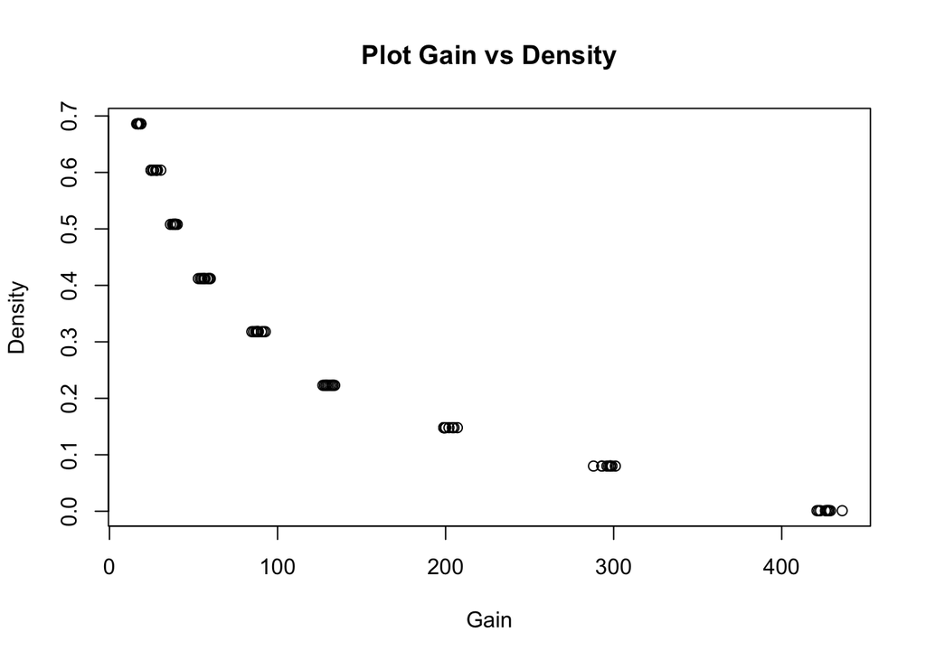

```r
plot(data$gain, data$density, xlab='Gain', ylab='Density', main='Plot Gain vs Density')
```

Fit line on original dataset

```r
fit <- lm(density~gain, data=data)
summary(fit)
```

```
##
## Call:
## lm(formula = density ~ gain, data = data)
##
## Residuals:
##      Min       1Q   Median       3Q      Max
## -0.13198 -0.09452 -0.01354  0.09682  0.16495
##
## Coefficients:
##               Estimate Std. Error t value Pr(>|t|)
## (Intercept)  0.5497239  0.0151243   36.35   <2e-16 ***
## gain        -0.0015334  0.0000777  -19.73   <2e-16 ***
## ---
## Signif. codes:  0 '***' 0.001 '**' 0.01 '*' 0.05 '.' 0.1 ' ' 1
##
## Residual standard error: 0.09769 on 88 degrees of freedom
## Multiple R-squared:  0.8157, Adjusted R-squared:  0.8136
## F-statistic: 389.5 on 1 and 88 DF,  p-value: < 2.2e-16
```

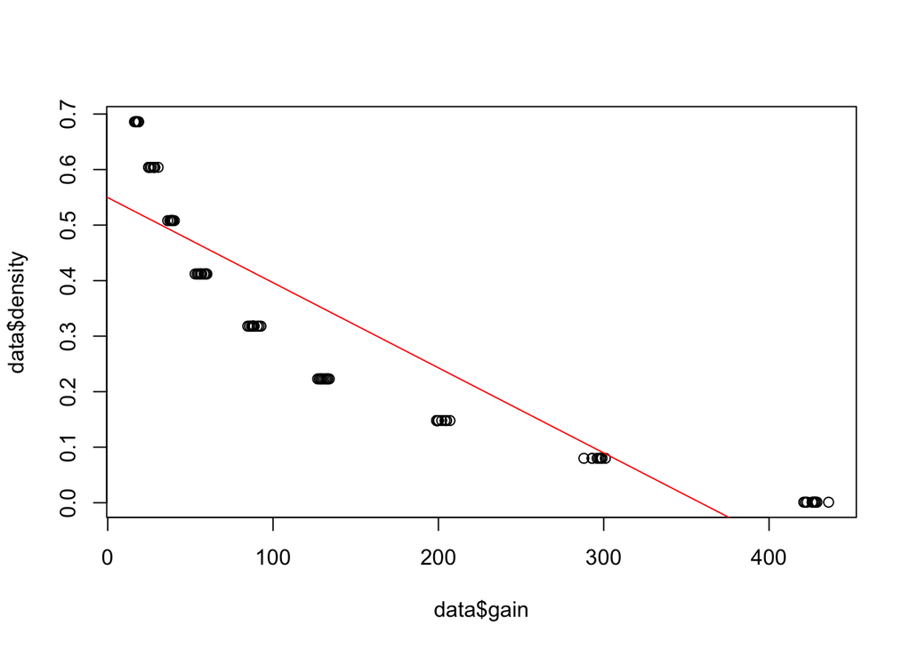

```r
plot(data$gain, data$density)
abline(fit, col="red")
```

```r
res.log <- as.numeric(residuals(fit))
library(moments)
kurt_res = kurtosis(res.log)
cat("The kurtosis of the distribution of residuals is: ",kurt_res)
```

```
## The kurtosis of the distribution of residuals is:  1.715274
```

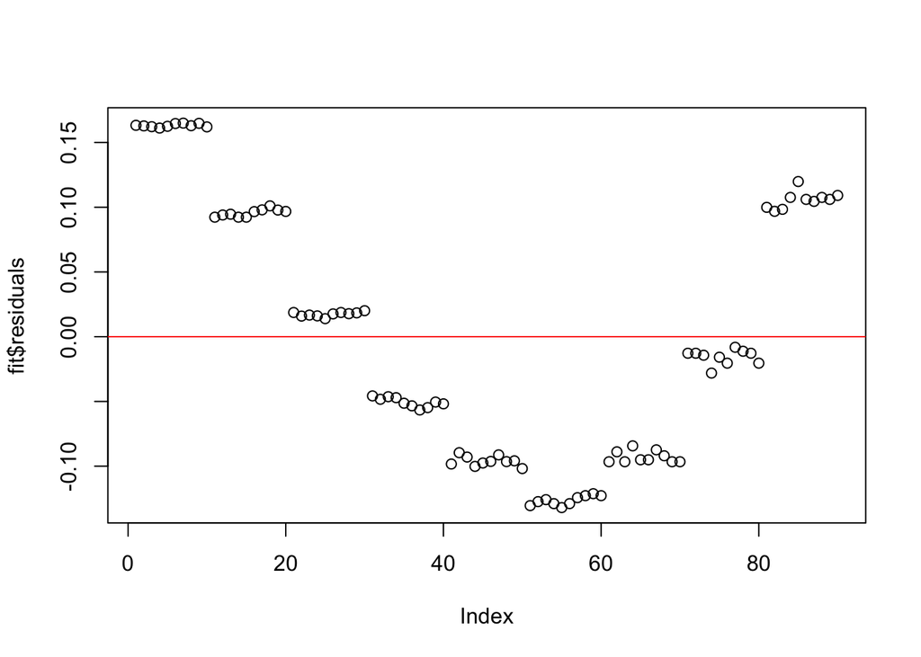

```r
plot(fit$residuals)
abline(0, 0, col="red")
```

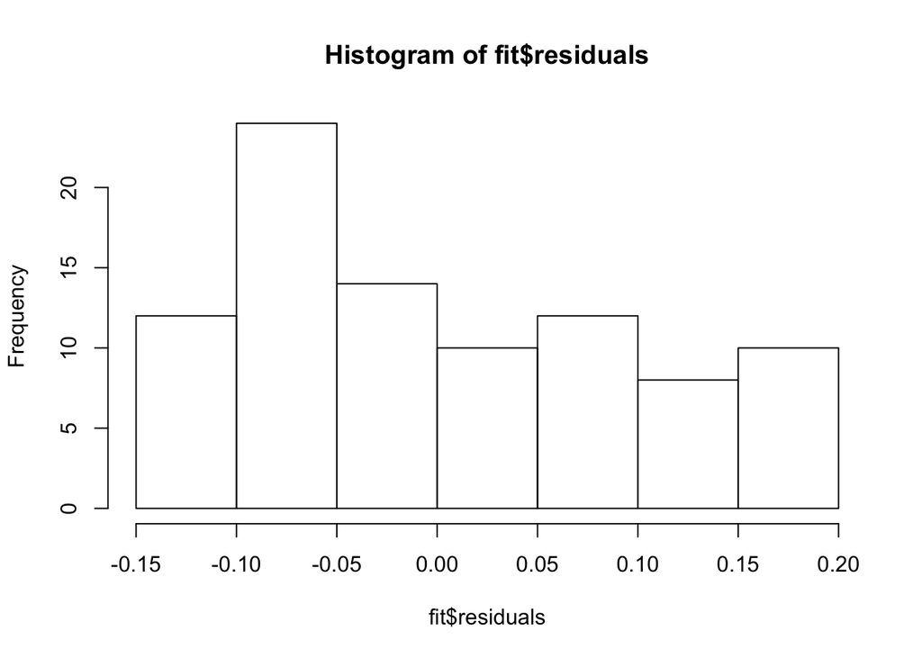

```r
hist(fit$residuals)
```

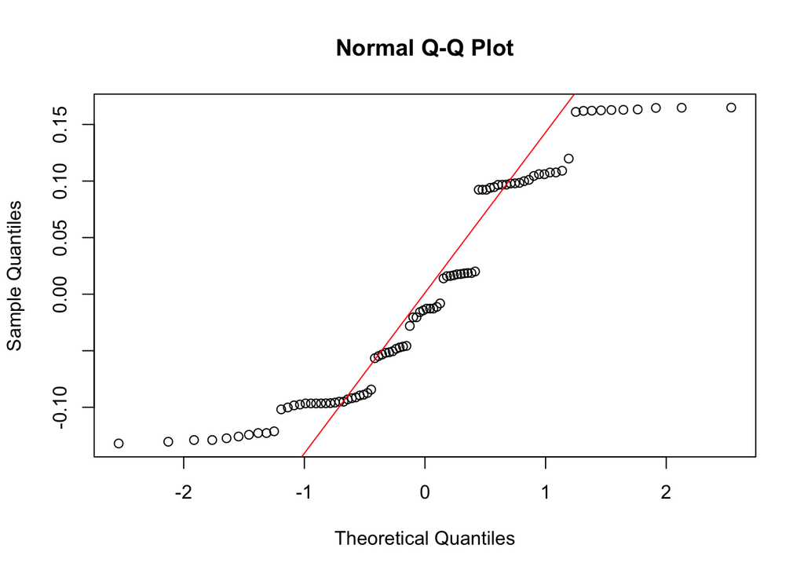

```r
qqnorm(fit$residuals)
qqline(fit$residuals, col="red")
```

From plotting the residuals we can see a pattern from each group of densities. The residuals follows a quadratic curve and do not appear to show randonmess within each density.

```r
sd(data$gain)
```

```
## [1] 133.271
```

```r
mean(data$gain)
```

```
## [1] 142.5667
```

(WRITING NOT MINE DETAILS MAY BE WRONG)

Our data follows a hyperbolic curvature and has extreme variability since the mean of the gain is 142.57 and the standard deviation is 133.27, which are unusually proportional to each other. With highly skewed data if we make a transformation that will give us a linearity we will be able to fit a straight line with higher accuracy. Here we will make a log transformation such that y′=log(y) where y′ will be our transformed data that we will call log.gain

```r
data$log.gain = log(data$gain)
fit2 = lm(log.gain~density, data=data)
summary(fit2)
```

```
##
## Call:
## lm(formula = log.gain ~ density, data = data)
##
## Residuals:
##       Min        1Q    Median        3Q       Max
## -0.131216 -0.052396 -0.004436  0.054607  0.202447
##
## Coefficients:
##             Estimate Std. Error t value Pr(>|t|)
## (Intercept)  5.99727    0.01274   470.8   <2e-16 ***
## density     -4.60594    0.03182  -144.8   <2e-16 ***
## ---
## Signif. codes:  0 '***' 0.001 '**' 0.01 '*' 0.05 '.' 0.1 ' ' 1
##
## Residual standard error: 0.06792 on 88 degrees of freedom
## Multiple R-squared:  0.9958, Adjusted R-squared:  0.9958
## F-statistic: 2.096e+04 on 1 and 88 DF,  p-value: < 2.2e-16
```

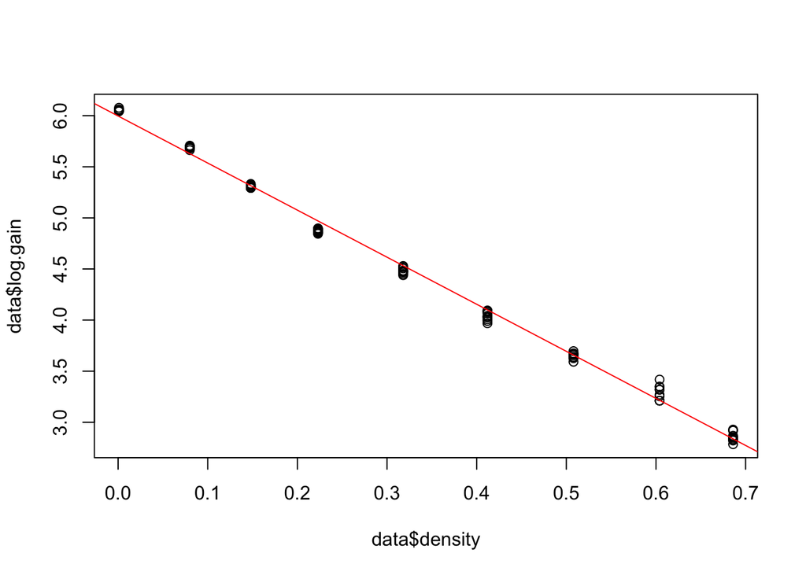

```r
plot(data$density,data$log.gain)
abline(fit2, col="red")
```

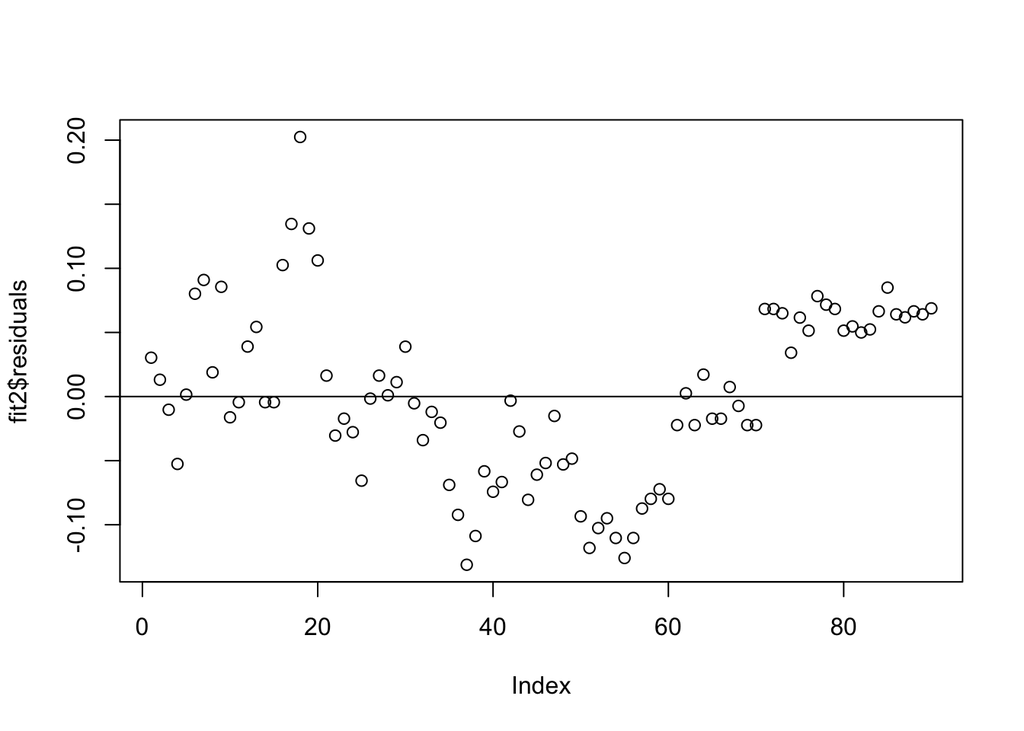

```r
plot(fit2$residuals)
abline(0, 0, col="black")
```

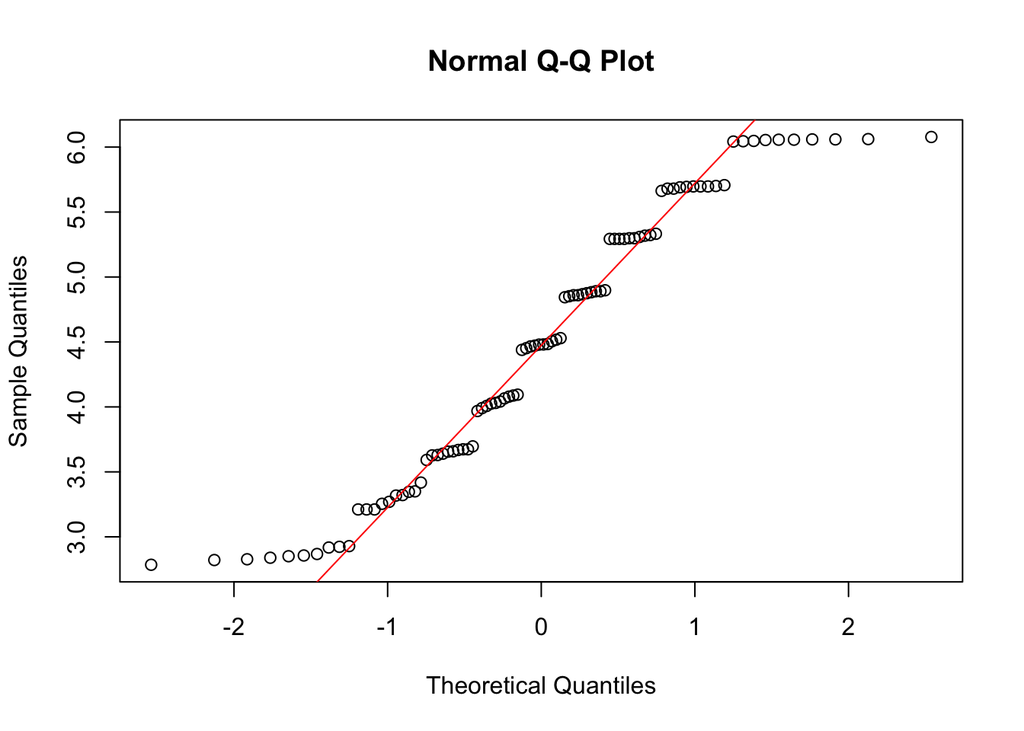

```r
qqnorm(data$log.gain)
qqline(data$log.gain, col="red")
```

From this plot of the residuals we can see much more randomness between the distances from our fitted line and the observed data. The residuals on the left half are centered around 0, however, on the right appears to show less randomness and doesn’t center around 0.

## Density Error

```r
#read in "gauge.txt" into data
data <- read.table("gauge.txt", header=TRUE)
head(data)
```

```
##   density gain
## 1   0.686 17.6
## 2   0.686 17.3
## 3   0.686 16.9
## 4   0.686 16.2
## 5   0.686 17.1
## 6   0.686 18.5
```

```r
nrow(data)
```

```
## [1] 90
```

```r
data$density <- round(data$density, digits=1)
head(data)
```

```
##   density gain
## 1     0.7 17.6
## 2     0.7 17.3
## 3     0.7 16.9
## 4     0.7 16.2
## 5     0.7 17.1
## 6     0.7 18.5
```

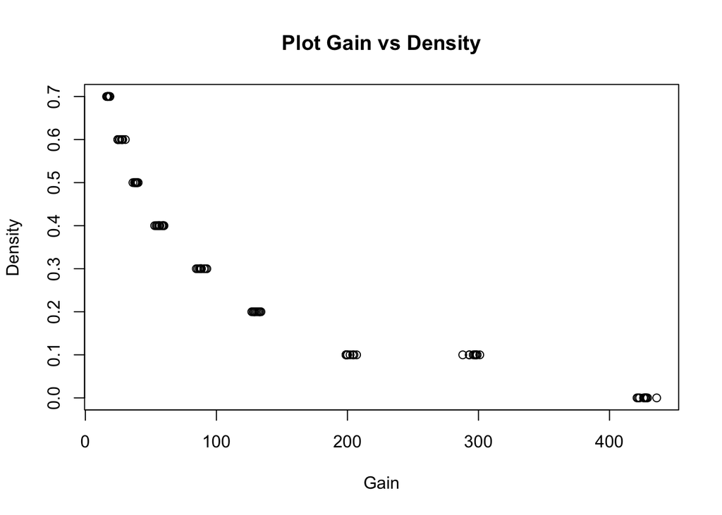

```r
plot(data$gain, data$density, xlab='Gain', ylab='Density', main='Plot Gain vs Density')
```

```r
fit <- lm(density~gain, data=data)
summary(fit)
```

```
##
## Call:
## lm(formula = density ~ gain, data = data)
##
## Residuals:
##      Min       1Q   Median       3Q      Max
## -0.14592 -0.10661  0.01361  0.10290  0.18924
##
## Coefficients:
##               Estimate Std. Error t value Pr(>|t|)
## (Intercept)  5.392e-01  1.726e-02   31.25   <2e-16 ***
## gain        -1.522e-03  8.865e-05  -17.17   <2e-16 ***
## ---
## Signif. codes:  0 '***' 0.001 '**' 0.01 '*' 0.05 '.' 0.1 ' ' 1
##
## Residual standard error: 0.1115 on 88 degrees of freedom
## Multiple R-squared:  0.7701, Adjusted R-squared:  0.7675
## F-statistic: 294.8 on 1 and 88 DF,  p-value: < 2.2e-16
```

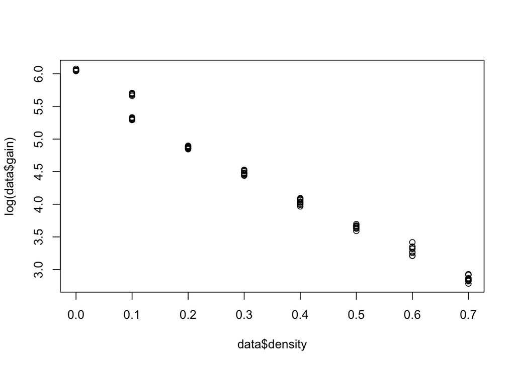

```r
plot(data$density, log(data$gain))
```